# Study 2: T1 and correlations for hormones and SNAG

Shuying Yu

11/26/2022

*Modified on:* December 23rd, 2022

# Overview

This report provides exploratory and preliminary correlation analyses between sex hormones and T1 hippocampal ROI data extracted from AAL for the Healthy Aging Study sample that have completed spatial navigation behavior. Mask was selected for left and right hippocampus, using 2D dilation 1 on registered (not smoothed) segmented grey matter using Wake Forest University PickAtlas and MarsBaR toolboxes in SPM12.

**Cleaning data steps included (T1 hipp):**

1. Filter participants that have T1 data from scan and have completed spatial
2. Select sex hormone measures from when spatial was conducted
3. Average left and right volumes to get a single measure
4. Correct averaged volume with TIV

Sample size and age for women and men grouped by overall completion of spatial navigation behavior with T1 scan.

| Sex | Overall n | Overall Mean Age | Overall SD Age | LOOP n | LOOP Mean Age | LOOP SD Age | MAZE n | MAZE Mean Age | MAZE SD Age | DSP n | DSP Mean Age | DSP SD Age |
| --- | --- | --- | --- | --- | --- | --- | --- | --- | --- | --- | --- | --- |
| Female | 74 | 50.69 | 3.72 | 26 | 50.23 | 3.70 | 61 | 50.28 | 3.49 | 46 | 50.30 | 3.53 |
| Male | 32 | 50.53 | 4.13 | 18 | 50.78 | 4.21 | 22 | 50.14 | 4.28 | 26 | 50.15 | 4.10 |

Above table shows the table of sample size and mean and standard deviation of age by sex for overall group who have completed spatial behavior and have a T1 scan.

All sample size for T1 x hormone correlations for women are listed in the table above. For men, because some participants did not have all hormones evaluated (e.g, only testosterone available), the sample size for the correlations for that hormone and with T1 hipp volume will be different.

For men, the accurate sample sizes would be:

- LOOP: *n* = 16 DHEAS, *n* = 18 for SHBG and T
- MAZE: *n* = 21 DHEAS, *n* = 22 for SHBG and T
- DSP: *n* = 25 DHEAS, *n* = 26 for SHBG and T

# Structural Distributions

Shapiro-Wilks test reveals that the average T1 hipp volume for all groups (overall, women, men) were normally distributed.

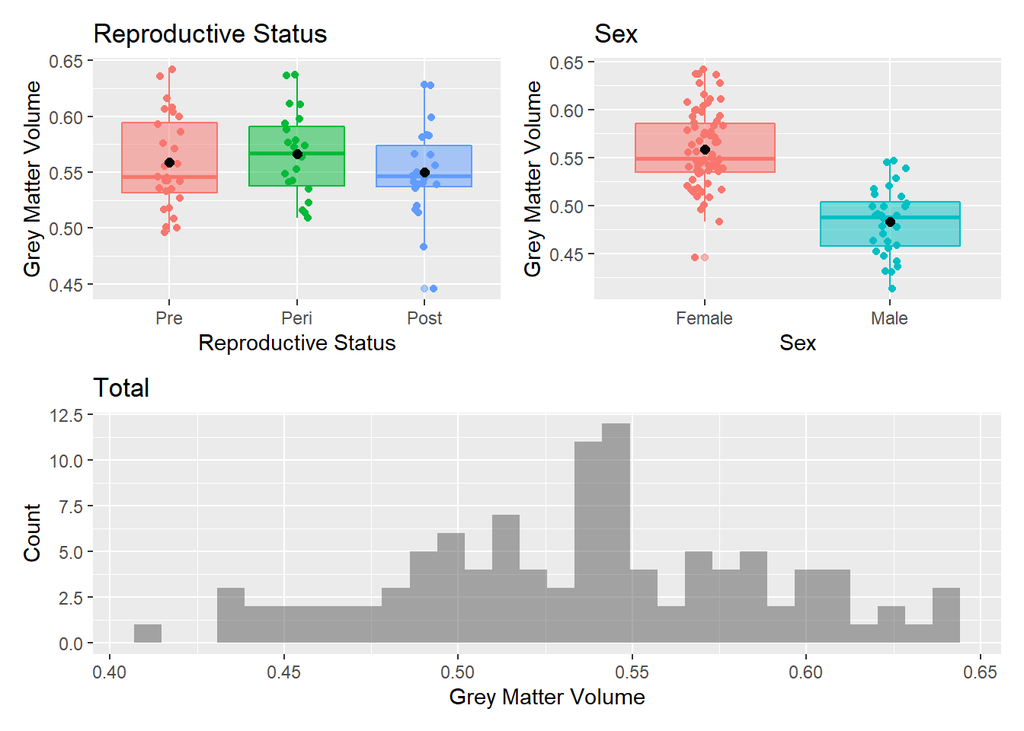

Box plot shows the women appear to have greater T1 hippocampal GMV than men.

Sample size and means for subjects by sex with T1 hipp volume and completed spatial navigation behavior

| Sex | n | Mean Total Hipp Volume | SD Total Hipp Volume |
| --- | --- | --- | --- |
| Pre | 28 | 0.56 | 0.04 |
| Peri | 23 | 0.57 | 0.04 |
| Post | 23 | 0.55 | 0.04 |

Sample size and means for subjects by sex with T1 hipp volume and completed spatial navigation behavior

| Sex | n | Mean Total Hipp Volume | SD Total Hipp Volume |
| --- | --- | --- | --- |
| Female | 74 | 0.56 | 0.04 |
| Male | 32 | 0.48 | 0.03 |

ANOVA results comparing T1 hipp GMV by reproductive status was not significant.

T-test results comparing GMV by sex was significant. Women (*M* = 0.558) have larger T1 hippocampal volume than men (*M* = 0.483) (*t* = 9.722, *df* = 67.914, *p* = 0).

# T1 and Hormone

We know that estradiol, progesterone, and FSH distributions are skewed, so we can either apply log transformations or move forward with Spearman rank correlations. Despite log transformations, hormones were still significant (different than normal), so correlations will be Spearman rank correlations with raw hormone values for women.

For men, DHEAS was not normal so Spearman rank correlation will be applied for these associations with T1 hipp GMV.

## Hormone Correlation by Reproductive Status

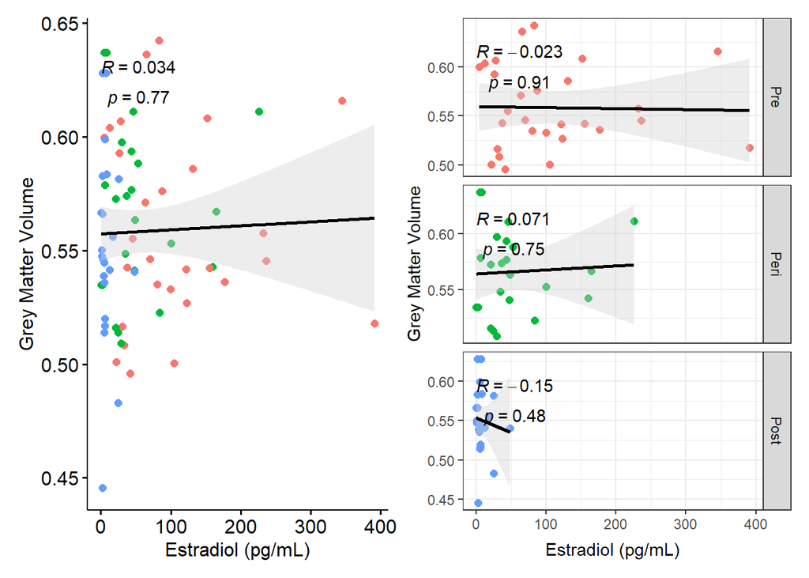

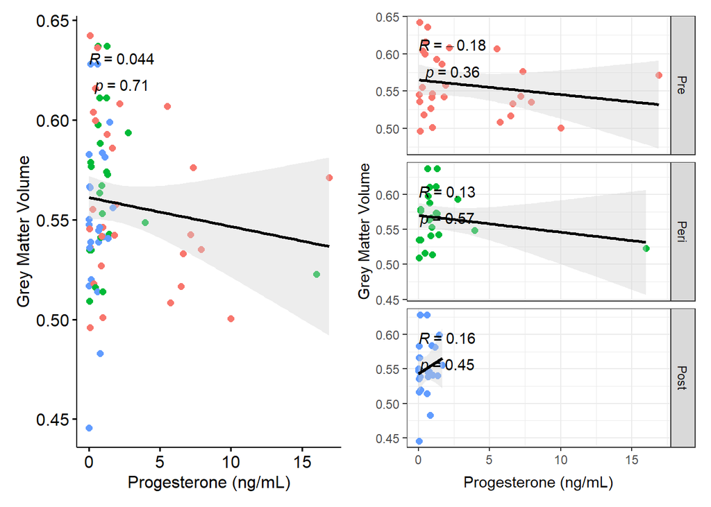

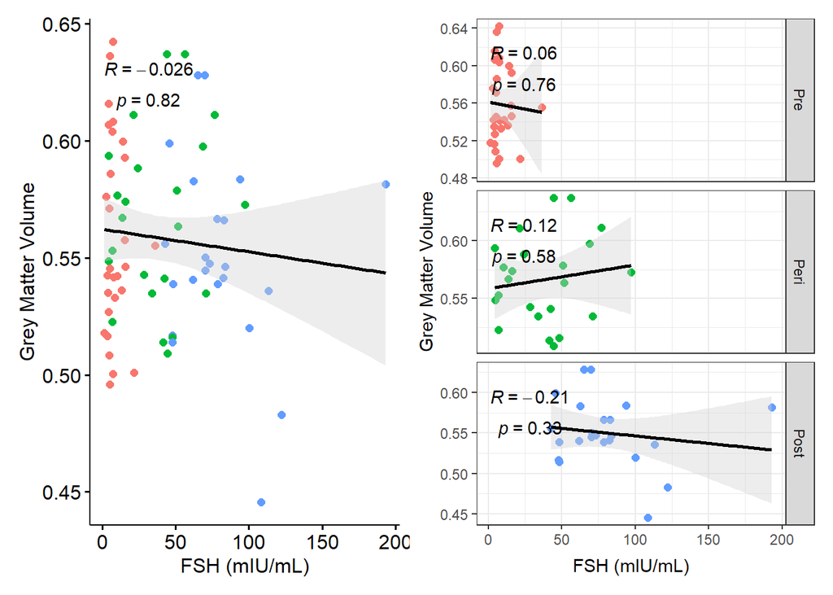

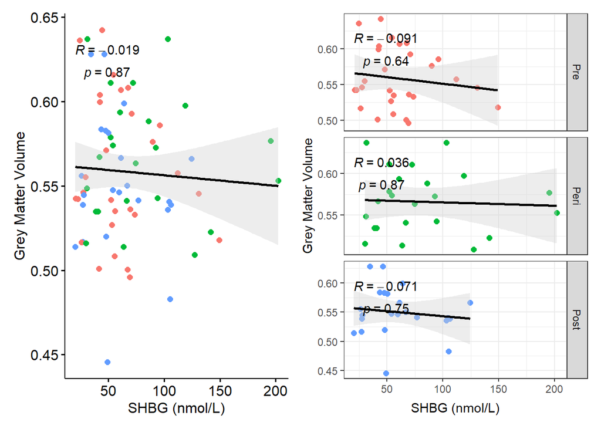

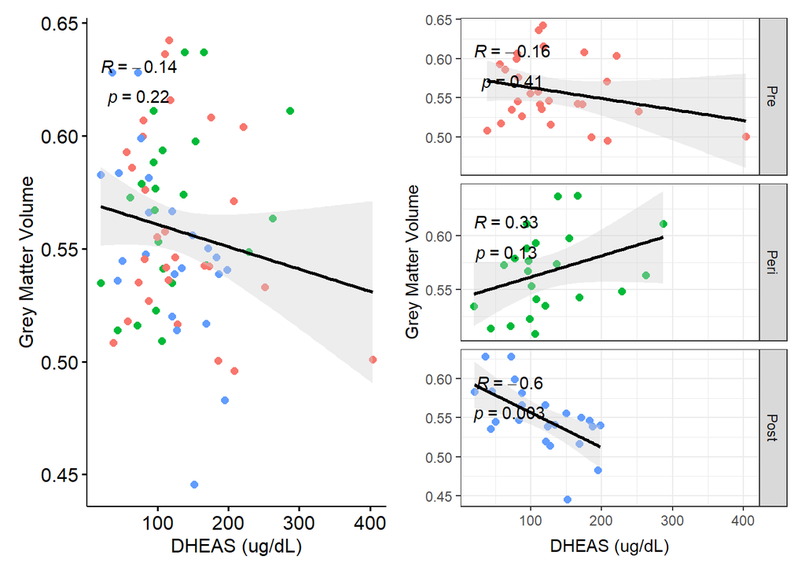

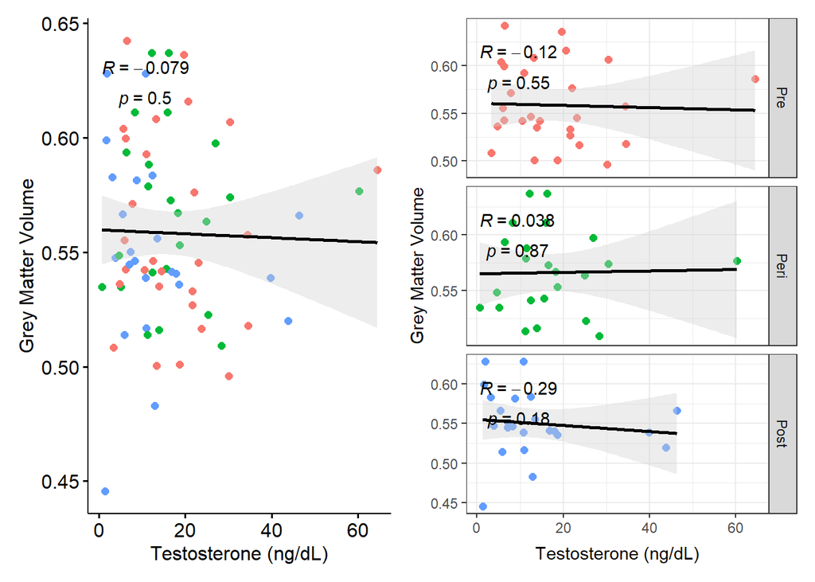

All correlations are Spearman rank. DHEAS was negatively correlated with T1 hippocampal GMV for posts (*p* < 0.01).

## Hormone Correlation by Men

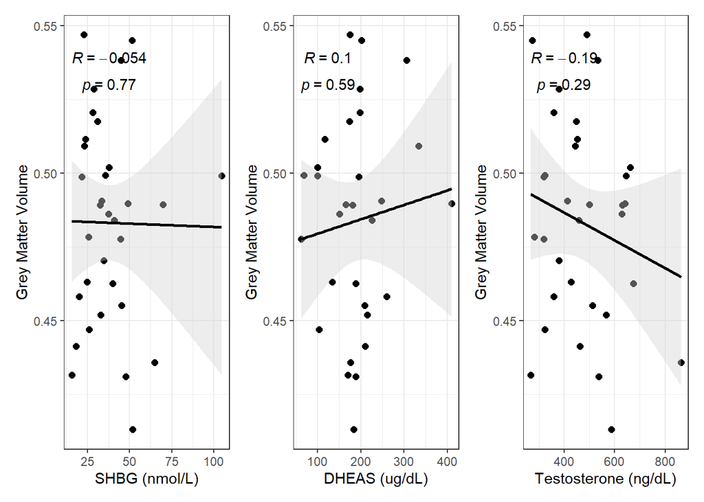

# T1 and Behavior

**Overall:**

Shapiro-Wilk’s test reveal that LOOP position error at 3.0m, degrees traveled averaged, angular error at 3.0m; and DSP wayfinding success are normally distributed, but MAZE dependent variables and DSP solution index and DSP path efficiency are not. Thus, all correlations with GMV for these DV will be spearman rank correlations.

**Women:**

LOOP average angualr error, MAZE dependent variables, and DSP solution index and path efficiency were significantly different than normal. These dependent variables for women will be using Spearman rank correlation.

Like the overall distributions, LOOP DVs look normal but MAZE and DSP variables appear skewed.

**Men:**

LOOP degrees traveled at 3.0m, MAZE accuracy, and DSP solution index were significantly different from normal. Spearman rank correlations will be applied for associations with GMV for men here.

## LOOP

### Position Error

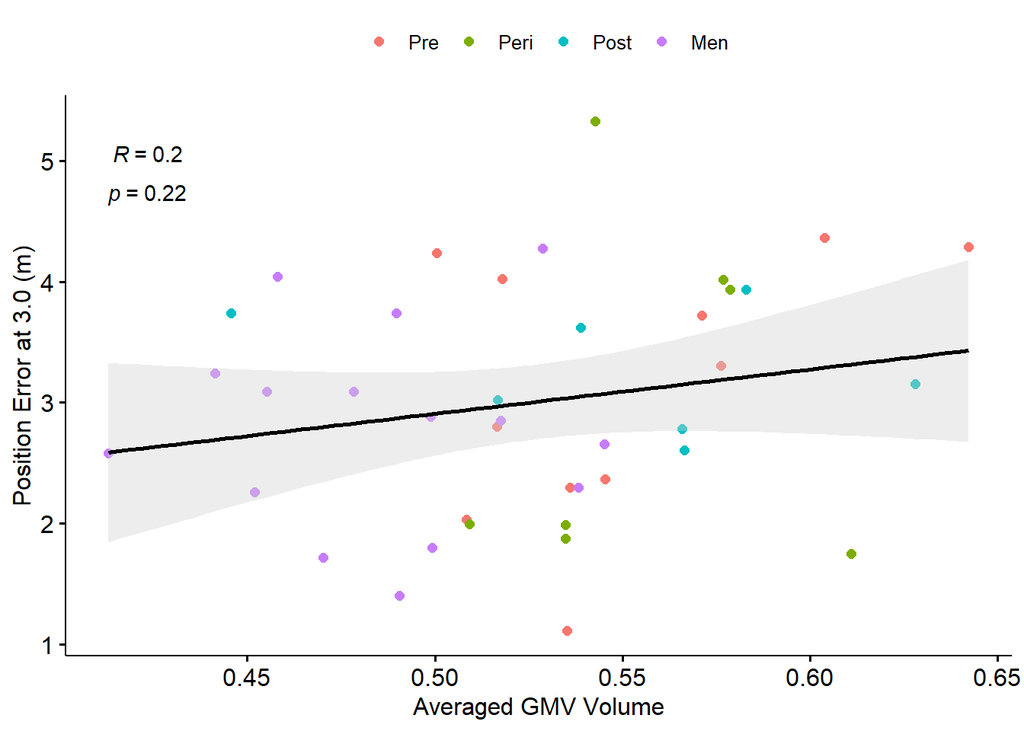

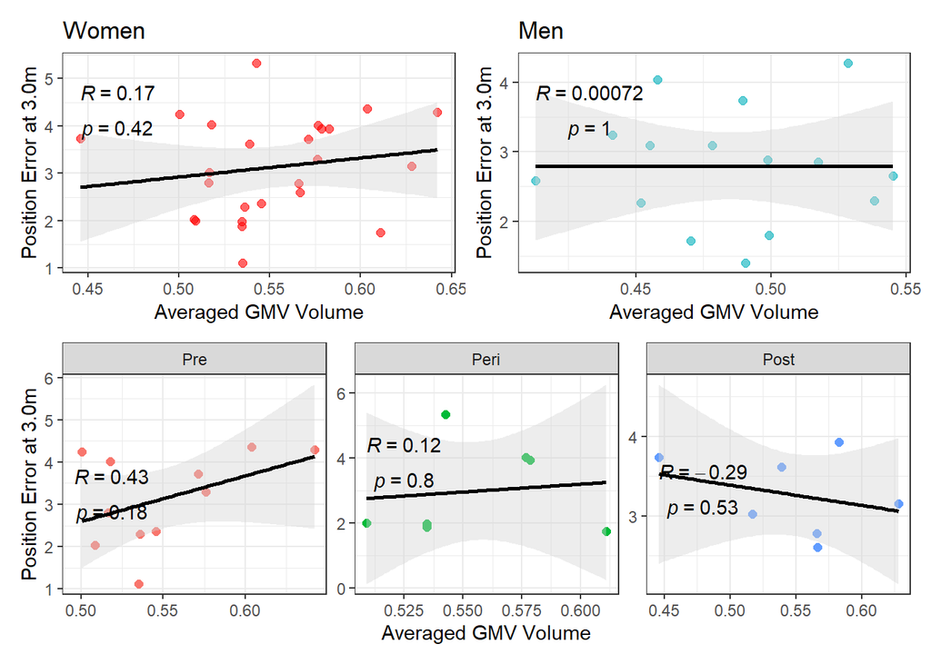

All are Pearson correlations.

### Degrees Traveled

#### 3.0m

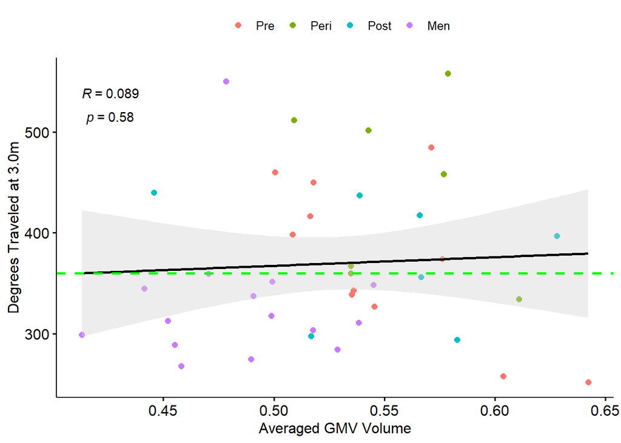

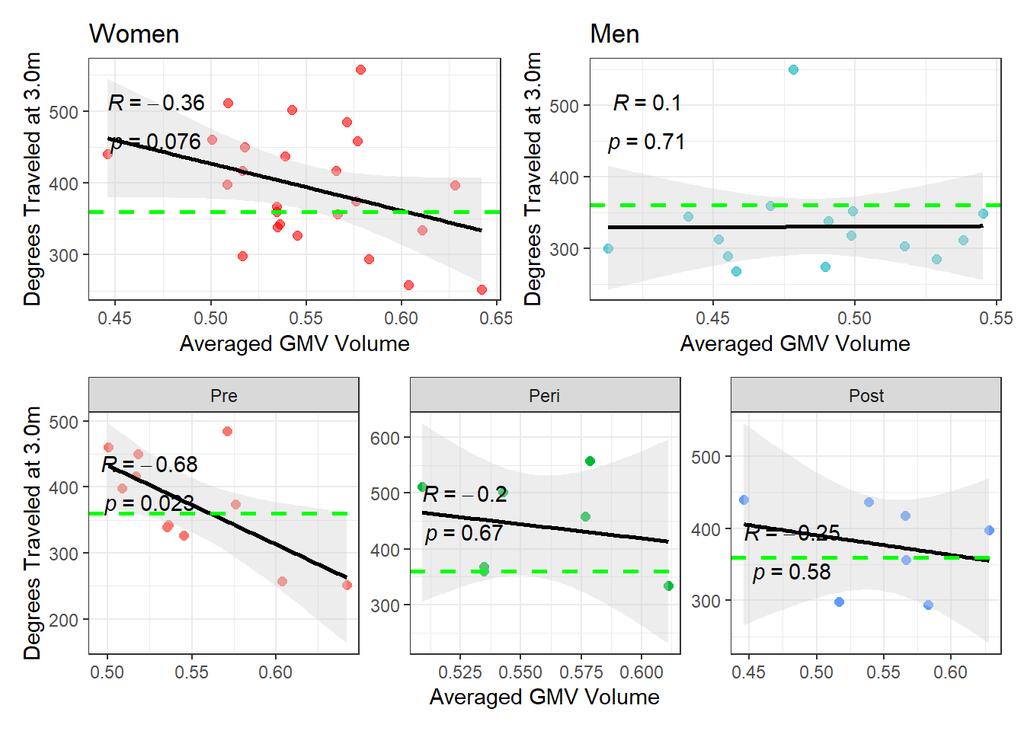

All correlations were Spearman except for women (Pearson). Women with higher GMV marginally correlated with fewer degrees traveled at 3.0m (*p* = 0.07, Pearson). Pres who had higher GMV correlated with lower degrees traveled at 3.0m (*p* < 0.05, Pearson).

#### Averaged

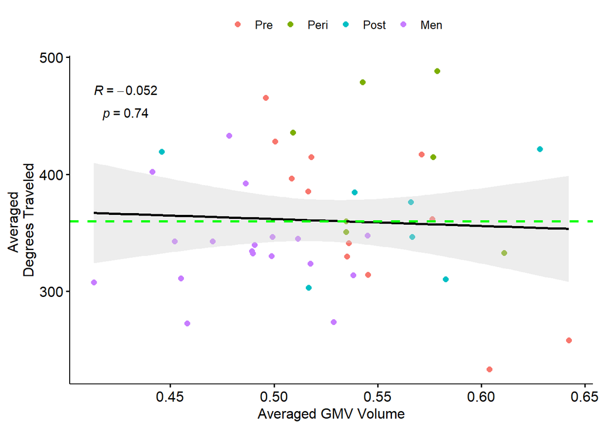

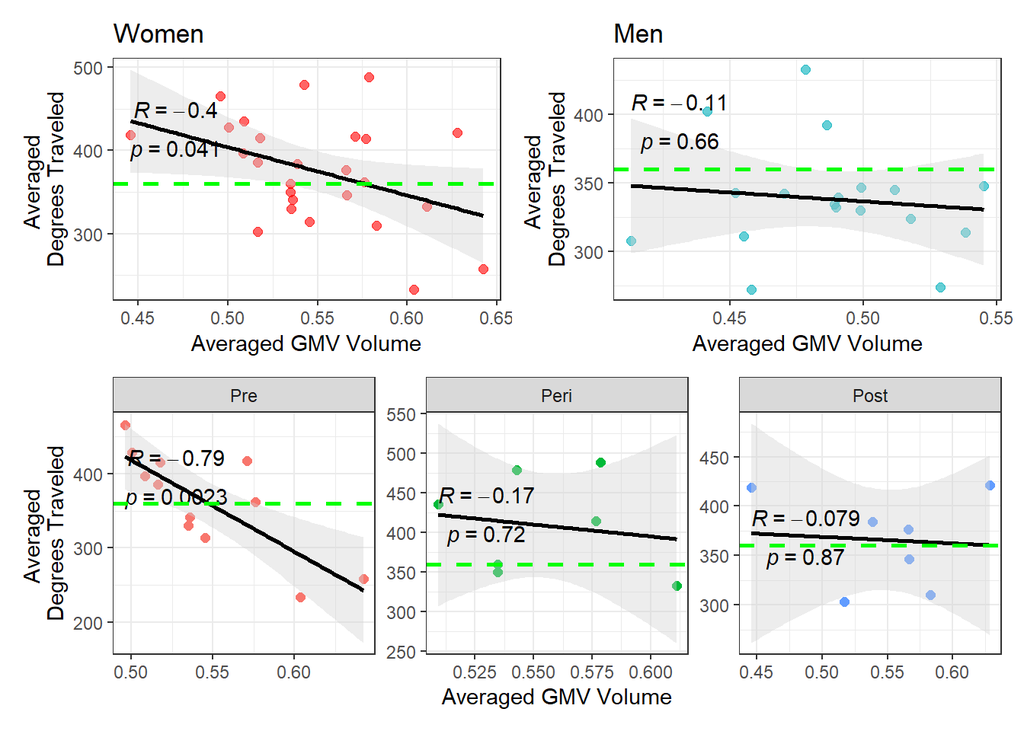

All correlations are Pearson. Women with higher GMV correlated with fewer degrees traveled (*p* < 0.05, Pearson). Pres who had higher GMV correlated with lower degrees traveled (*p* < 0.01, Pearson).

### Angular Error

#### 3.0m

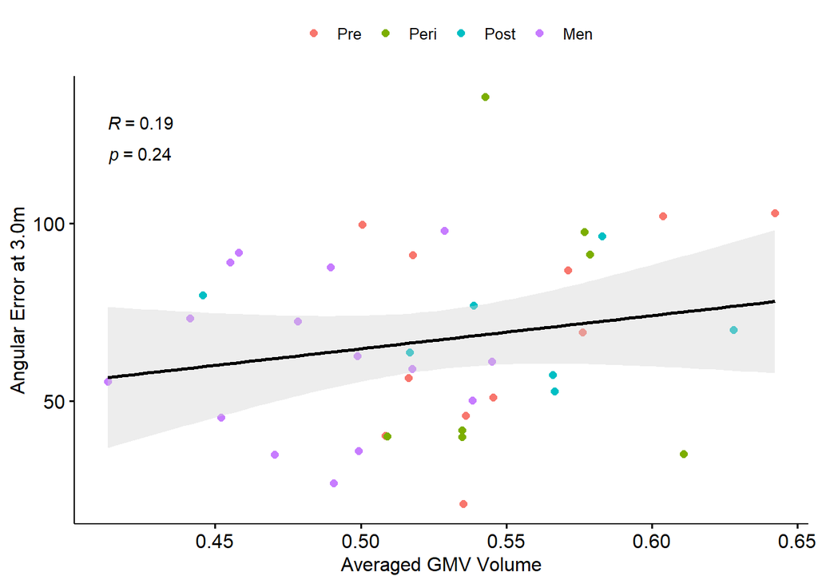

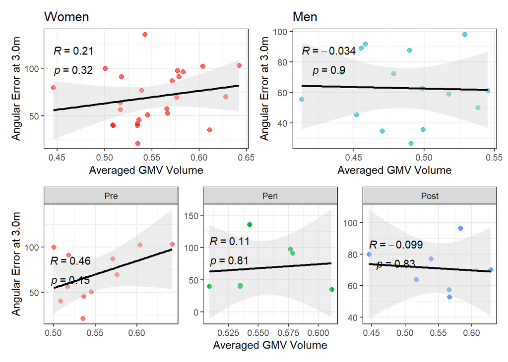

All correlations were Pearson.

#### Averaged

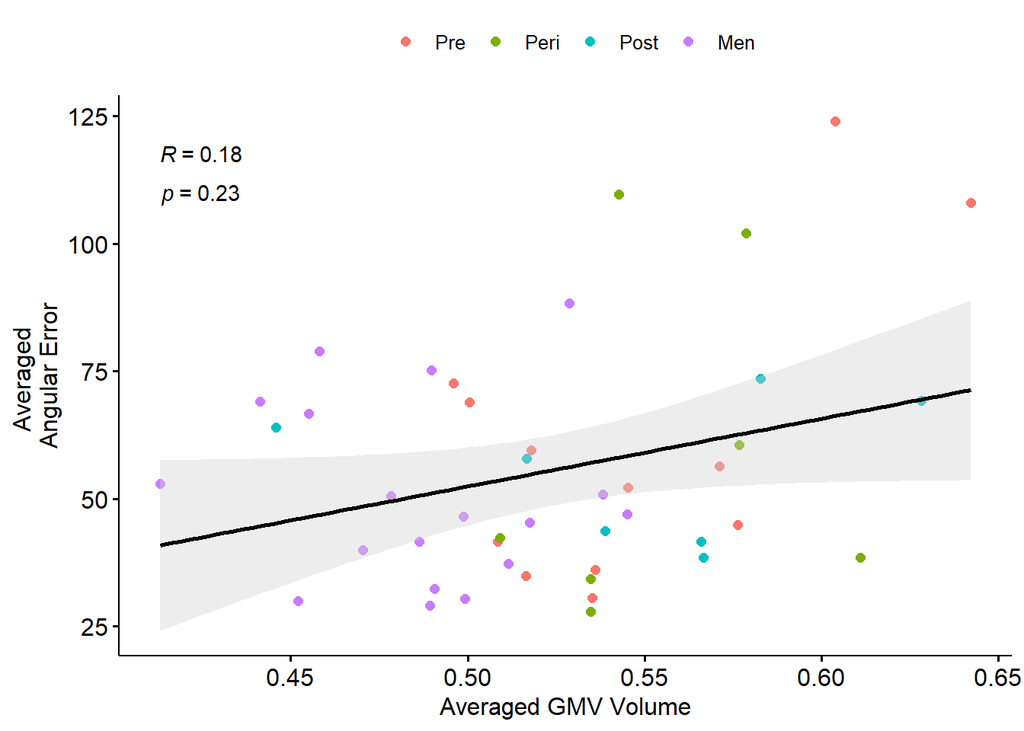

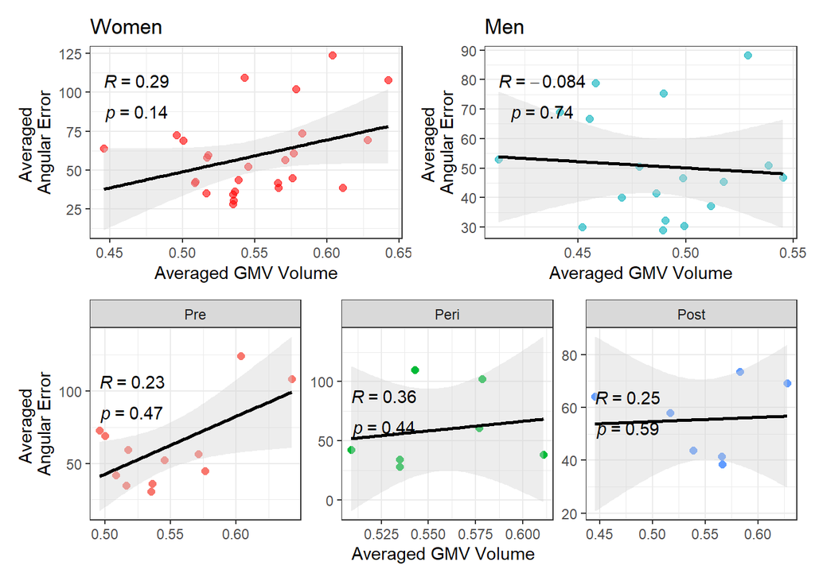

All correlations were Spearman except for men (Pearson)

## MAZE

### Accuracy

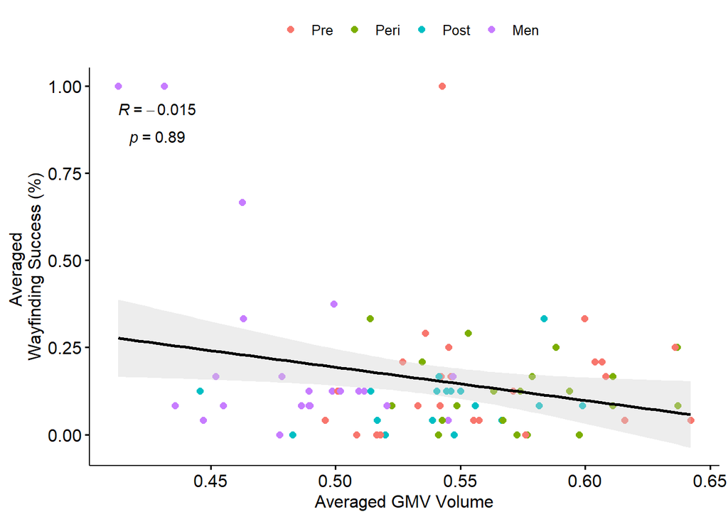

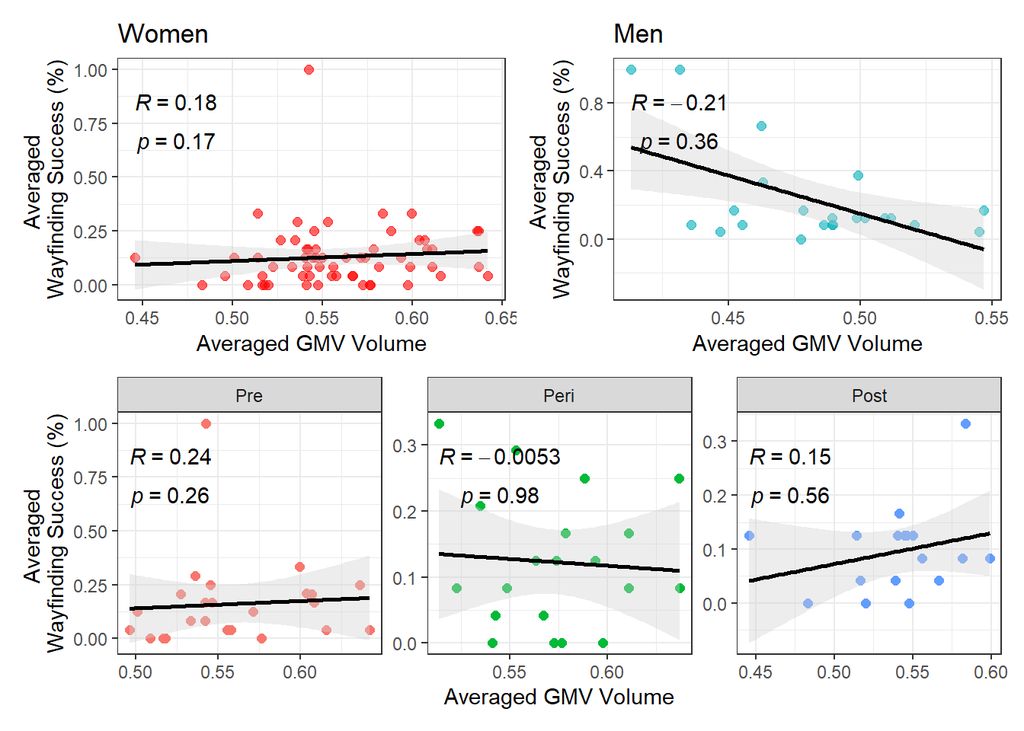

All correlations are Spearman.

### Moves

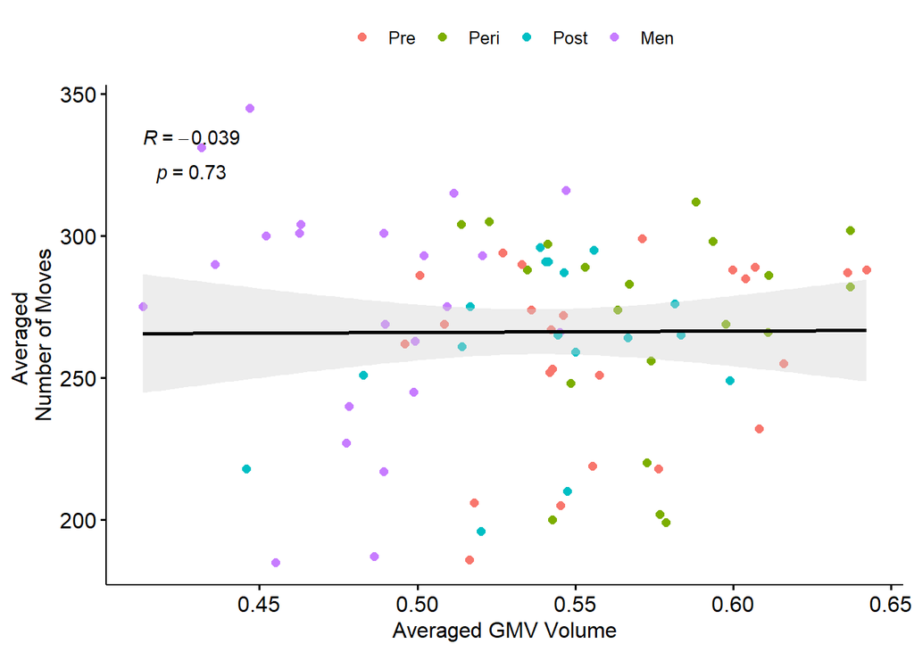

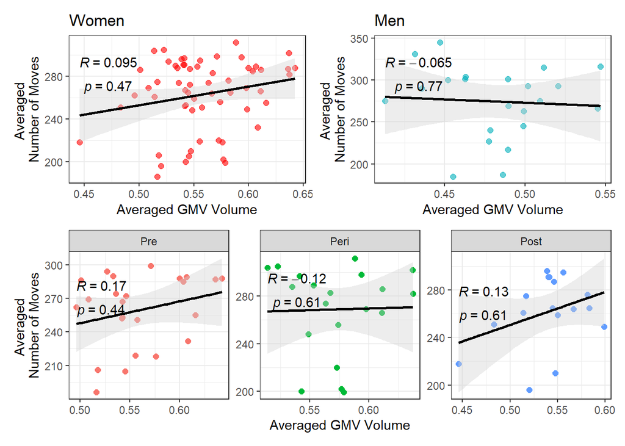

All Spearman correlations except for men (Pearson)

### Path Efficiency

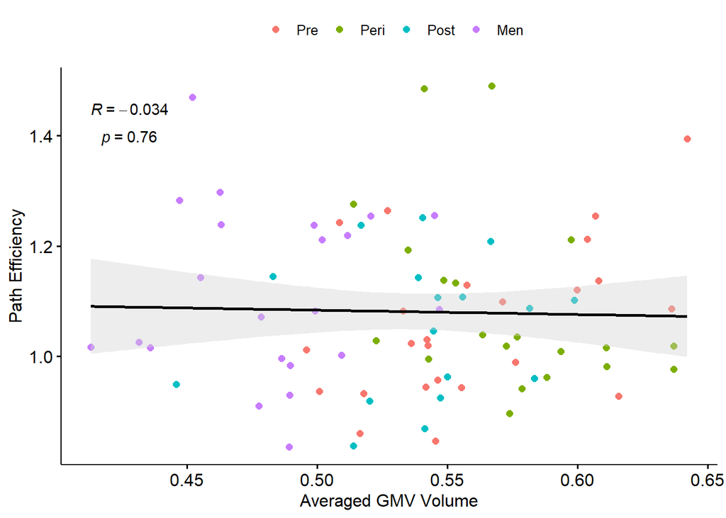

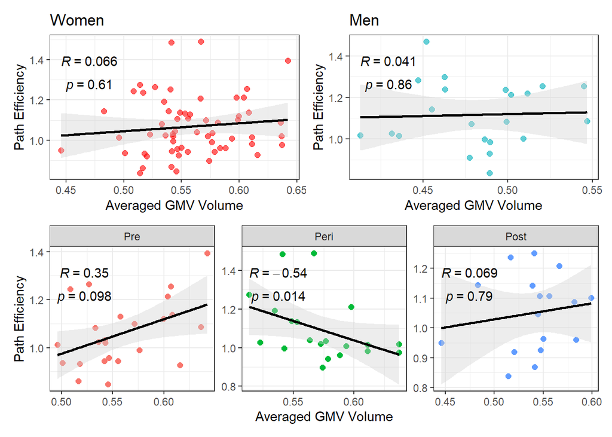

All Spearman correlations except for men (Pearson). Higher average GMV volume was negatively correlated with path efficiency for peri-menopausal women (*p* < 0.05, Spearman)

## DSP

### Wayfinding Success

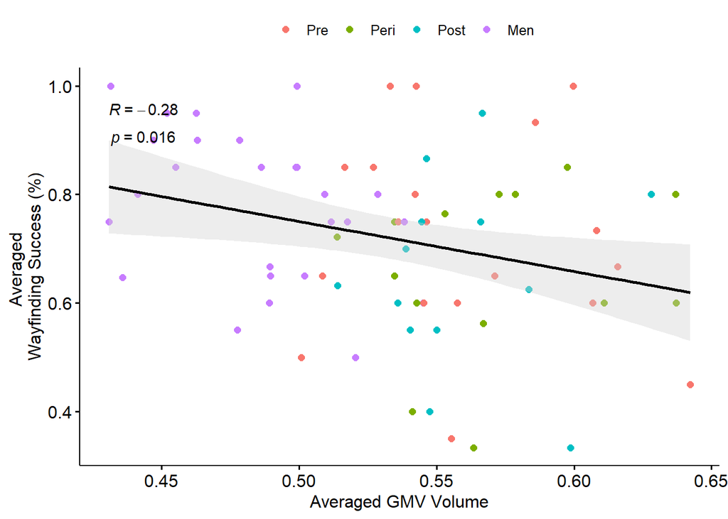

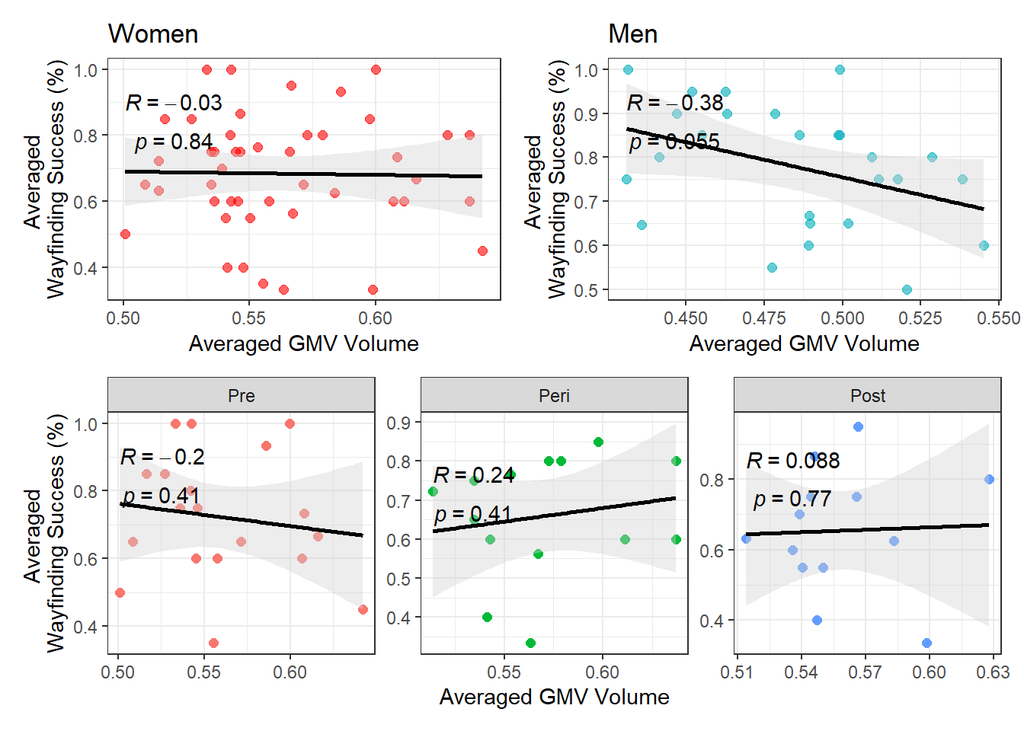

All correlations were Pearson except for women groups (Spearman). Overall, larger T1 hipp GMV was associated with lower wayfinding success in DSP (*p* < 0.05, Pearson). This pattern was also observed marginally in men (*p* = 0.055, Pearson), but not in women (*p* = 0.84, Spearman).

### Solution Index

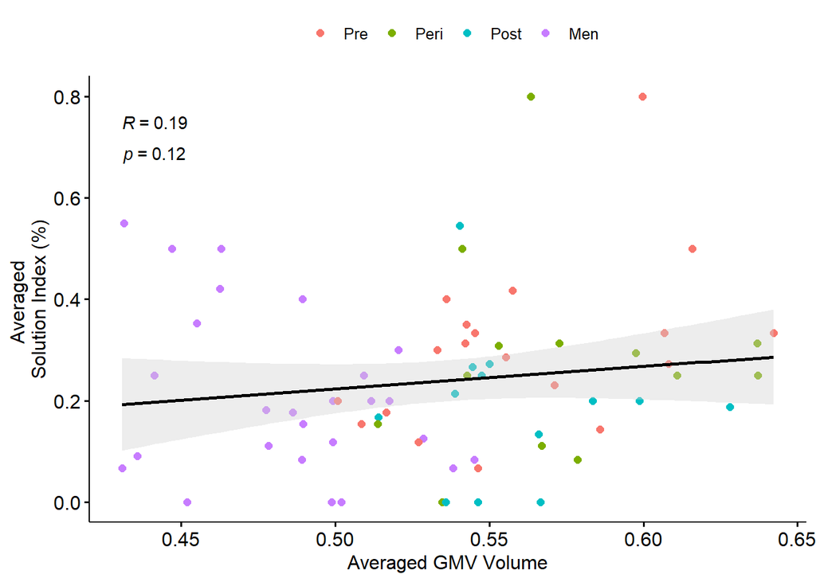

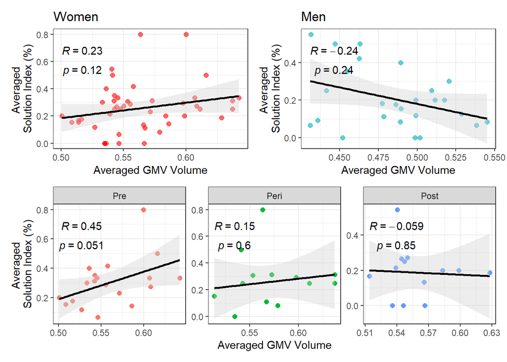

All correlations are Spearman except for women groups (Spearman). T1 volume is positively marginally associated with DSP solution index in pres (*p* = 0.051, Pearson).

### Path Efficiency

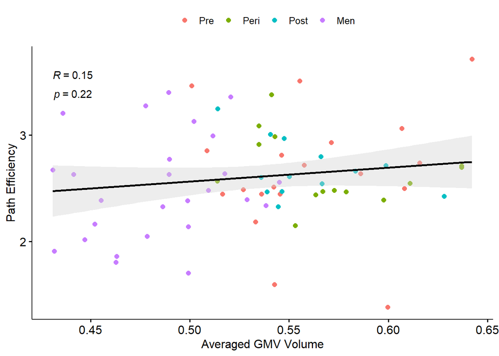

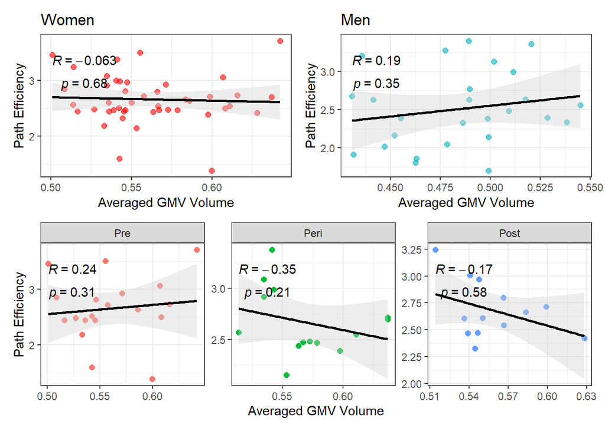

All correlations were Pearson except for women (Spearman)

# Summary

Sample included HAS participants who had a T1 scan and completed spatial navigation behavior

## Behavior

- For LOOP, women with higher GMV marginally correlated with fewer degrees traveled at 3.0m (*p* = 0.07, Pearson). Pres who had higher GMV correlated with lower degrees traveled at 3.0m (*p* < 0.05, Pearson). Similarly, women with higher GMV correlated with lower averaged degrees traveled (*p* < 0.05, Pearson). Pres who had higher GMV also correlated with lower averaged degrees traveled (*p* < 0.01, Pearson).
- For MAZE, higher average GMV volume was negatively correlated with path efficiency for peri-menopausal women (*p* < 0.05, Spearman).
- For DSP, overall (women and men) higher T1 hipp GMV was associated with lower wayfinding success in DSP (*p* < 0.05, Pearson). This pattern was also observed marginally in men (*p* = 0.055, Pearson), but not in women (*p* = 0.84, Spearman). Higher DSP solution index was marginally positively associated with pres who had higher GMV (*p* = 0.051, Pearson).